Sources: https://www.coursera.org/lecture/financial-risk-management-with-r/calculating-daily-returns-jenBp https://www.coursera.org/lecture/financial-risk-management-with-r/calculating-longer-returns-m1ZnI

```r
library(quantmod)
wil<-getSymbols("WILL5000IND",src="FRED",auto.assign=FALSE)
```

[output not shown]

```r
wil<-na.omit(wil)
wil<-wil["1979-12-31/2017-12-31"]
names(wil)<-"TR"
head(wil,3)
```

```
##              TR
## 1979-12-31 1.90
## 1980-01-02 1.86
## 1980-01-04 1.88
```

```r
tail(wil,3)
```

```
##                TR
## 2017-12-27 124.04
## 2017-12-28 124.33
## 2017-12-29 123.67
```

```r
logreturn <- diff(log(wil$TR))[-1]
round(head(logreturn, 3),6)
```

```
##                   TR
## 1980-01-02 -0.021277
## 1980-01-04  0.010695
## 1980-01-07  0.005305
```

daily return : $re$$t_t$$=$$wil_t$$/$$wil_{t-1}$$-1$

A discrete return can never have a value less than -1, but it can take on a positive number greater than 1. This mean that the distrubution of discrete returns cannot have a symetric distrobution, so we should transform by taking the log of the data

$logre$$t_t$$=log(1+$$ret_t$$)$

To get a n-day return simply add up all the daily returns

```r
logreturn_w <- apply.weekly(wil,sum) #also works for monthly, quarterly, and yearly
round(head(logreturn_w,3),6)
```

```
##              TR
## 1980-01-04 5.64
## 1980-01-11 9.65
## 1980-01-18 9.84
```

```r
mu <- round(mean(logreturn),8)
sigma <- round(sd(logreturn),8)
mu
```

```
## [1] 0.00043575
```

```r
sigma
```

```
## [1] 0.01072056
```

Value at risk (VaR): the ammount that the portfolio might lose, with a given probability (1 - alpha) over a given time period (alpha is usually 0.1, o.05 or 0.01) and the time period is usually one day or one week

```r
round(qnorm(0.05,mu,sigma),6)
```

```
## [1] -0.017198
```

The meaning of this number is that over the period of one single day the fund is not likely to loose more than 1.72% of its value at a 95% confidence interval

Expected shortfall (ES): for the same values as VaR, the ES is the expected return given that the return is less than the assoiated VaR; conditional value at risk (CaR), expected tail-loss;

```r
ES<-mu-sigma*dnorm(qnorm(0.05,0,1),0,1)/0.05
discreteES<-exp(ES)-1 #converting it back to a discrete return, rather than logarithmic
discreteES
```

```
## [1] -0.02144441
```

The one day expected loss (ES) at the 95% conidence level is -2.14% if the loss is greater than the VaR

Principal: to estimate the alpha-quantile of a distribution, simulate some data, and then calculate the alpha-quantile of the simulation (this goves the VaR at the (1-alpha) confidence interval)

The mean of the data less the VaR is the ES

```r
alpha<-0.05
set.seed(123456789)
rvec<-rnorm(10000,mu,sigma)
VaR<-quantile(rvec,alpha)
ES<-mean(rvec[rvec<VaR])
round(VaR,6)
```

```
##        5%
## -0.017351
```

```r
round(ES,6)
```

```
## [1] -0.021854
```

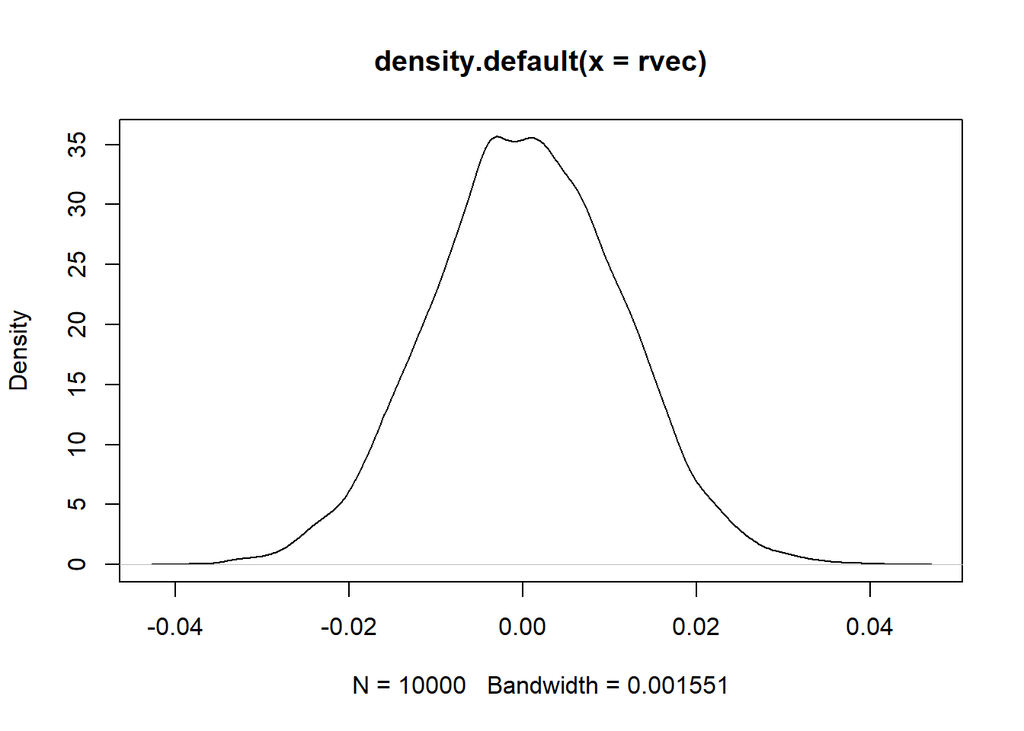

```r
plot(density(rvec))
```

Now with replacement, where we replace the sampled in the distribution This does not assume normality, since we are replacing elements of the data When we compare the graphs of the rvec from before and after replacement, we can see that replacement causes the distrobution to look less normal

```r
alpha<-0.05
set.seed(123456789)
rvec<-sample(as.vector(logreturn),100000,replace=TRUE)
VaR<-quantile(rvec,alpha)
ES<-mean(rvec[rvec<VaR])
round(VaR,6)
```

```
##        5%
## -0.016065
```

```r
round(ES,6)
```

```
## [1] -0.025789
```

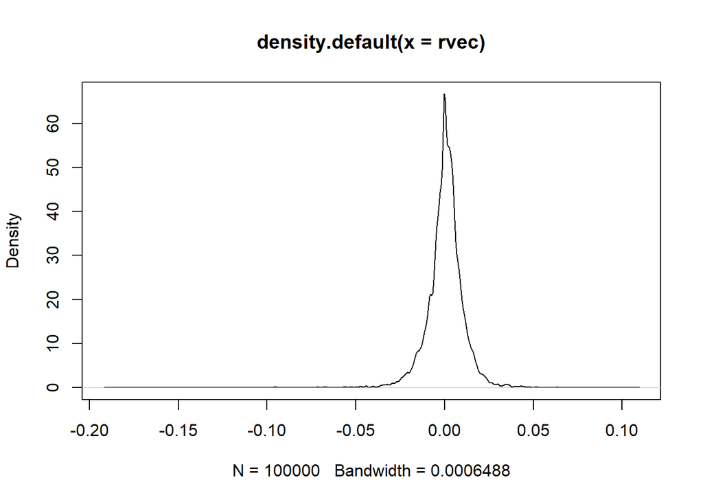

```r
plot(density(rvec))
```

Kurtosis : over or under thickness of the central point Coefecient of skewkness: 0 if symetric greater than 0 if right skewed and less than 0 if left skewed Coeffecient of kurtosis: a measure of the heavness or thickness of the tails of a distribution: 3 for normal : les than 3 for thin-tailed: more than 3 for thick-tailed

```r
library(moments)
rvec <- as.vector(logreturn)
round(kurtosis(rvec),3) #heavy-tailed
```

```
## [1] 21.804
```

Many ways to test for normality…one is the Jarque-Bera test

```r
library(moments)
rvec<-as.vector(logreturn)
jarque.test(rvec) #test for normality
```

```
##
##  Jarque-Bera Normality Test
##
## data:  rvec
## JB = 142514, p-value < 2.2e-16
## alternative hypothesis: greater
```

Rejects the hypotheseis that the data is normal

Student-t distribution can be used to describe heavy-tailed distributions The pram v of degrees of freedom DoF controls the Student-t always has a mean of 0, coef of skewness 0 as long as v greater than 3 When v is infinite, the distribution is normal N(0,1) REmember that the kurtosis of the Wil5000 was ~22, so (through some online chart) the v or DoF is ~4.3 BUT, it is unlikely to find a v that matches the sd and kurtosis of the data at the same time SOLUTION: add in another coeffecient to help solve the problem :divide every outcome by the sd, which in this case is the sqrt(v/(v-2))

this effectivley re-scales the student-t distrobution

So now we have a new model called the rescalled t distrobution model

It has three parameters (mu (mean), sigma (standard deviation aka scaling parameter), nu (dof))

######Estimating the three parameters: We will use MLE (maximum likeleyhood estimation), which is one of the most important methods in statistics. It works off of the idea the you should pick parameters that will give you the highest proability of observing the data. The sample mean is the best estimate of the total mean. Use the MASS package and “fisdist” to do all this stuff…:)

```r
library(MASS)
rvec<-as.vector(logreturn)
t.fit<-fitdistr(rvec, "t")
round(t.fit$estimate,6)
```

```
##        m        s       df
## 0.000754 0.006641 3.043844
```

```r
alpha<-0.05
set.seed(123456789)
library(metRology)
rvec<-rt.scaled(100000,mean=t.fit$estimate[1],sd=t.fit$estimate[2],df=t.fit$estimate[3])
VaR<-quantile(rvec,alpha)
ES<-mean(rvec[rvec<VaR])
round(VaR,6)
```

```
##        5%
## -0.014647
```

```r
round(ES,6)
```

```
## [1] -0.024546
```

####Time horizons that are longer than 1 day

The first way to do this is to simply re-use the student-t distribution and add up 10 of the one-day log values for VaR and ES

```r
alpha<-0.05
set.seed(123456789)
library(metRology)
rvec<-rep(0,100000)
for(i in 1:10){
  rvec<-rvec+rt.scaled(100000,mean=t.fit$estimate[1],sd=t.fit$estimate[2],df=t.fit$estimate[3])
}
VaR<-quantile(rvec,alpha)
ES<-mean(rvec[rvec<VaR])
VaR
```

```
##          5%
## -0.04746437
```

```r
ES
```

```
## [1] -0.0703273
```

Another method (IID simulation) is basicially an extension for the one day returns where you simply extrapolate from the known data It is called IID simulation (Independant and Indetically Distributed), we draw randomly form the past data, and the numbers drawn are drawn at random to be completely independant

```r
alpha<-0.05
set.seed(123456789)
rvec<-rep(0,100000)
for(i in 1:10){
  rvec<-rvec+sample(as.vector(logreturn),100000,replace=TRUE)
}
VaR<-quantile(rvec,alpha)
ES<-mean(rvec[rvec<VaR])
VaR
```

```
##          5%
## -0.05119792
```

```r
ES
```

```
## [1] -0.07203964
```

The third method is called block simulation, and it entails randomly picking a block of 10 consecutive 1-day log returns from the actual data and adding them all up to get a 10 day return. Thusly each of the simulations is independant from the other, but within the simulations, each day is not independant from the others. This method is the most interesting to me. This is different from the last method, becasue in the observed data we do not know if there is any time depandance across days, so the last method destroys any dependance between the days. If the data has no time dependance, then the methods B and C should give the same answers!

```r
alpha<-0.05
set.seed(123456789)
rvec<-rep(0,100000)
rdat<-as.vector(logreturn)
posn<-seq(from=1, to=length(rdat)-9, by=1)
rpos<-sample(posn, 100000, replace=TRUE)
for(i in 1:10){
  rvec<-rvec+rdat[rpos]
  rpos<-rpos+1
}
VaR<-quantile(rvec,alpha)
ES<-mean(rvec[rvec<VaR])
VaR
```

```
##          5%
## -0.04700005
```

```r
ES
```

```
## [1] -0.07683208
```

Since the last two results are not the same (and have a significant difference), we can concluded that the days returns are slightly dependant

The two assumptions that we have made so far: one: the future distribution will look similar to the historical distribution. However, there is no way to tell if the future will mirror the past. Two: we are estimateing the parameters of the furure distribution, without considering the ordering of the data. i.e. with the t distribution we used an r function that does not care about the ordering of the parameters.

Now, lets condider whether the ordering of the parameters actually matters. This assumtion if actually testable:

First test: look for serial correlation. Positive serial correlation: an above average return is followed by another above average return. Negative serial correlation: an above average return is followed by a below-average return. No serial correlation (“random-walk”): an above average return does no increase the likelyhood of another above average return

Testing for serial correlation can be used to test for market effeciency. $x_t$ : the value of a time series on day t $p_j = cor($x_t$, $x_{t-j}$)$